# Data Vizzes using R

## Demonstration for CAMP, June 2026

# Welcome

Hello, fellow CAMPRs! In this tutorial, we’ll explore how to create some basic (and a few more advanced) data visualizations using R in the context of institutional research, planning, and effectiveness (IRPE). We’ll be using fake data (because FERPA, and I’m not trying to get fired) to demonstrate how to create various types of visualizations.

Imagine that as the **College of Awesome Metrics and Planning (CAMP)**, we are working with datasets related to student demographics and academic outcomes, in relation to basic needs insecurity.

## Why R?

R has become one of my primary tools for communicating institutional research. Although many people associate R with statistics, I spend much more time using it to create reports, visualizations, and interactive elements than actually running stats.

This tutorial provides an overview of the workflow I use to develop vizzes for IRPE. Rather than focusing on advanced programming, the goal is to demonstrate how R can support reproducible, accessible, and publication-quality reporting.

## R workflow

Most viz projects follow the same general process.

Import Data ↓ Clean & Prepare ↓ Decide Data Story ↓ Choose Visualization ↓ Making it Pretty (Style & Brand ) ↓ Accessibility Review ↓ Publish (PDF/HTML)

This tutorial mainly focuses on visualization, making it pretty, and accessibility.

## Decide the data story

Before writing any code, we first need to decide *what* we want to visualize and the message we want the audience to takeaway. In a report such as this, we often write the takeaway, but we also want them to look at a chart and see that supporting evidence. After all, pictures + words = more convincing –> more funding? I wish.

However, with R, there’s an extra layer to this. Not only do we need to know what kind of visualization (e.g., bar chart, line chart, heatmap, histogram), we also need to figure out what visualization approach works best for the audience and story.

### Three main visualization approaches

- Base
- ggplot2 package
- plotly package

| Feature | Base R | ggplot2 | Plotly |
| --- | --- | --- | --- |
| Learning curve | ★☆☆ | ★★☆ | ★★★ |
| Ease of customization | Low | High | Very High |
| Publication-quality graphics | Limited | Excellent | Good |
| Interactive | No | No | Yes |
| Hover information | No | No | Yes |
| Dropdowns / buttons | No | No | Yes |
| Suitable for PDFs | Yes | Excellent | Limited |
| Suitable for HTML | Basic | Good | Excellent |
| Accessibility support | Manual | Good (Quarto `fig-alt`) | Manual (ARIA labels, hover text) |
| Branding / themes | Limited | Excellent | Excellent |
| Automation | Good | Excellent | Excellent |
| Best use case | Quick exploration | Reports & presentations | Dashboards & web reports |

# Creating an example dataset

**You can probably skip this entire section.** I included this part simply for transparency so you can see how the data was structured and how it came about.

These steps for data creation are just for this tutorial. Normally, you wouldn’t be making up your own data (I hope). This would be the “data cleaning” part of the data vizzes.

To get started, let’s create some fake data that we can use for our visualizations. We’ll create a dataset that includes information about students, such as their demographics, academic performance, and engagement metrics.

## About the datasets

Let’s pretend that we have two separate datasets, then we’ll merge them for one “clean” dataset.

### Creating the survey dataset

The first dataset will be a survey dataset that includes information about students’ basic needs insecurity, based on the RealCollegeCA survey on basic needs administered by The RP Group with the Community College League of California. This dataset will have a `student_id` column since that was optional in the survey, along with all of their basic needs outcomes. This survey was administered in 2023 and 2025, so we have two years of data.

Instead of actual demographics, let’s make up a “superpower” variable that represents students’ superpower because now CAMP is also a college that enrolls students with superpowers. This will allow us to demonstrate how to create visualizations based on categorical variables.

```r
set.seed(123)

n_2023    <- 1800
n_2023_NA <- 450
n_2025    <- 2000
n_2025_NA <- 500

superpowers <- c("Flight", "Invisibility", "Super Strength", "Telepathy", "Teleportation")

all_ids  <- sample(1000000:9999999, (n_2023 - n_2023_NA) + (n_2025 - n_2025_NA), replace = FALSE)
ids_2023 <- all_ids[1:(n_2023 - n_2023_NA)]
ids_2025 <- all_ids[(n_2023 - n_2023_NA + 1):length(all_ids)]

sp_food     <- c(Flight = 0.45, Invisibility = 0.60, `Super Strength` = 0.48, Telepathy = 0.65, Teleportation = 0.42)
sp_housing  <- c(Flight = 0.40, Invisibility = 0.58, `Super Strength` = 0.44, Telepathy = 0.62, Teleportation = 0.38)
sp_homeless <- c(Flight = 0.15, Invisibility = 0.28, `Super Strength` = 0.17, Telepathy = 0.30, Teleportation = 0.13)

# Assign superpowers: 80% get one, 20% get two (no duplicates within a row)
assign_superpowers <- function(n, sp_probs) {
  has_two <- rbinom(n, 1, 0.20) == 1  # 20% get two superpowers

  sapply(seq_len(n), function(i) {
    if (has_two[i]) {
      # Sample 2 without replacement
      paste(sample(superpowers, 2, replace = FALSE, prob = sp_probs), collapse = ", ")
    } else {
      sample(superpowers, 1, prob = sp_probs)
    }
  })
}

# For outcomes, use the FIRST superpower listed to drive probabilities
# (the dominant power, so to speak)
get_primary_sp <- function(sp_vec) {
  trimws(sapply(strsplit(sp_vec, ","), `[`, 1))
}

make_df <- function(year, ids, n, n_na, sp_probs, food_bump = 0, housing_bump = 0, homeless_bump = 0) {
  sp     <- assign_superpowers(n, sp_probs)
  sp_pri <- get_primary_sp(sp)  # primary superpower drives outcome rates

  data.frame(
    year               = year,
    student_id         = sample(c(ids, rep(NA, n_na))),
    superpower         = sp,           # e.g. "Flight" or "Flight, Telepathy"
    superpower_primary = sp_pri,       # always a single value, used for outcome rates
    food_insecurity    = rbinom(n, 1, pmin(sp_food[sp_pri]    + food_bump,    1)),
    housing_insecurity = rbinom(n, 1, pmin(sp_housing[sp_pri] + housing_bump, 1)),
    homelessness       = rbinom(n, 1, pmin(sp_homeless[sp_pri] + homeless_bump, 1))
  )
}

df_2023 <- make_df(
  year     = 2023,
  ids      = ids_2023,
  n        = n_2023,
  n_na     = n_2023_NA,
  sp_probs = c(0.35, 0.25, 0.20, 0.12, 0.08)
)

df_2025 <- make_df(
  year          = 2025,
  ids           = ids_2025,
  n             = n_2025,
  n_na          = n_2025_NA,
  sp_probs      = c(0.20, 0.30, 0.15, 0.25, 0.10),
  food_bump     = 0.03,
  housing_bump  = 0.03,
  homeless_bump = 0.03
)

for (df_name in c("df_2023", "df_2025")) {
  df <- get(df_name)
  df$any_insecurity <- as.integer(
    df$food_insecurity    == 1 |
    df$housing_insecurity == 1 |
    df$homelessness       == 1
  )
  assign(df_name, df)
}

df_survey <- rbind(df_2023, df_2025)

write.csv(df_survey, here("data", "survey_data.csv"), row.names = FALSE)
```

Now we have a dataset called `df_survey` and a .csv file named “survey_data.csv” in our “Data” folder that contains information about students’ demographics (i.e., superpowers) and their basic needs insecurity status for the years 2023 and 2025.

### Creating the SIS dataset

Next, we need to create a second dataset that includes students’ academic outcomes. This dataset will also include the `student_id` column so that we can merge it with our survey dataset later on. Let’s pretend that we were able to pull this data from our student information system, but of course, we’re just making it up for this tutorial.

```r
# Pull non-NA student IDs from each survey year, along with their superpower,
# so persistence rates can vary by superpower
sis_2023 <- df_2023[!is.na(df_2023$student_id),c("student_id", "year", "superpower", "any_insecurity")]
sis_2025 <- df_2025[!is.na(df_2025$student_id), c("student_id", "year", "superpower", "any_insecurity")]

# Per-superpower persistence rates.
# Teleporters persist at high rates — they always show up (from anywhere lol).
# Telepaths struggle — too much noise in their heads to focus. Idk, this is made up.

# Retained within the term
sp_retain  <- c(Flight = 0.72, Invisibility = 0.65, `Super Strength` = 0.75, Telepathy = 0.60, Teleportation = 0.80)

# Persist to next term (i.e., re-enroll in following term)
sp_persist <- c(Flight = 0.32, Invisibility = 0.25, `Super Strength` = 0.35, Telepathy = 0.22, Teleportation = 0.38)

# Insecurity penalty — insecure students get these subtracted from their base rates
insec_retain_penalty  <- 0.12  # 12pp less likely to be retained
insec_persist_penalty <- 0.10  # 10pp less likely to persist

add_rates <- function(df) {

  # Base rates from superpower, then apply insecurity penalty
  p_persist <- sp_persist[df$superpower] - (df$any_insecurity * insec_persist_penalty)
  p_retain  <- sp_retain[df$superpower]  - (df$any_insecurity * insec_retain_penalty)

  # Cap between 0 and 1
  p_persist <- pmax(pmin(p_persist, 1), 0)
  p_retain  <- pmax(pmin(p_retain,  1), 0)

  df$persist <- rbinom(nrow(df), 1, p_persist)

  # retain: persist == 1 implies retain == 1;
  # otherwise draw from adjusted retain rate
  df$retain <- ifelse(
    df$persist == 1,
    1,
    rbinom(nrow(df), 1, p_retain)
  )

  df
}


sis_2023 <- add_rates(sis_2023)
sis_2025 <- add_rates(sis_2025)

# Stack into one SIS dataset
df_sis <- rbind(sis_2023, sis_2025)

# Since we had two separate datasets (survey/SIS), each with their superpower variable,
#we can drop the superpower/any_insec variable in the SIS dataset before merging so it's not duplicated
df_sis$superpower <- NULL
df_sis$any_insecurity <- NULL

# Save to CSV
write.csv(df_sis, here("data","sis_data.csv"), row.names = FALSE)
```

Yay! We now have two datasets: `df_survey` (saved as “survey_data.csv”) and `df_sis` (saved as “sis_data.csv”). The survey dataset contains information about students’ basic needs insecurity and their superpowers, while the SIS dataset contains information about their academic outcomes (retention and persistence).

Wait, but now we need to combine these datasets! We can merge them using the `student_id` column, which is the common identifier between the two datasets. This will allow us to analyze how basic needs insecurity relates to academic outcomes.

```r
# Read in the datasets (in practice, you would just read in the CSVs you already created)
df_survey <- read.csv(here("data","survey_data.csv"))
df_sis    <- read.csv(here("data","sis_data.csv"))

# If these were excel files, you would use read_xlsx() instead, like this:
# df_survey <- read_xlsx("data/survey_data.xlsx")


# Filter to only students who provided a student ID before merging.
# This is filtering using base R.
df_survey <- df_survey[!is.na(df_survey$student_id), ] # Remember [rows, columns] indexing.

# Alternatively, using dplyr, you could do:
# df_survey <- df_survey %>% filter(!is.na(student_id))
# OR if you want to keep people with telepathy only, you can do:
df_telepathy <- df_survey %>% filter(superpower == "Telepathy")
# OR if you want it by year
df_2023 <- df_survey %>% filter(year == 2023)

# Merge datasets on student_id and year
df <- merge(df_survey, df_sis, by = c("student_id", "year"), all.x = TRUE)
# all.x = TRUE keeps all rows from df_survey, even if there's no match in df_sis.

# Save to CSV
write.csv(df, here("data","data_clean.csv"), row.names = FALSE)
```

Woohoo! Now we’ve merged the data. We have a new dataset called `df` that contains all the information from both the survey and SIS datasets for students who provided their student ID. This dataset is saved as “data_clean.csv” in our “Data” folder.

This is our “raw data”.

But wait again! Before we jump into visualizations, let’s do some basic calculations to get the rates of food insecurity, housing insecurity, and homelessness by superpower. This will help us understand the data better and will be useful for creating our visualizations.

Additionally, since some students had two superpowers, they should be included in each group (e.g., invisibility + flight student is included in both invisibility and flight categories).

```r
# Calculate outcome rates by superpower

colnames(df) # Actually, i forgot what i named the columns
```

```
 [1] "student_id"         "year"               "superpower"
 [4] "superpower_primary" "food_insecurity"    "housing_insecurity"
 [7] "homelessness"       "any_insecurity"     "persist"
[10] "retain"
```

```r
# expand multi-superpower rows so each superpower gets its own row.
# A student with "Flight, Invisibility" becomes two rows — one for each.
# This means they're counted in both groups (inclusive method).
df_expanded <- df %>%
  mutate(superpower = strsplit(superpower, ", ")) %>%
  tidyr::unnest(superpower)

# Total respondents per year (for "n of total" in hover)
year_totals <- df_expanded %>%
  group_by(year) %>%
  summarise(total = n_distinct(student_id), .groups = "drop")

df_rates <- df_expanded %>%
  group_by(superpower, year) %>%
  summarise(
    `Food Insecurity`    = mean(food_insecurity,    na.rm = TRUE),
    `Housing Insecurity` = mean(housing_insecurity, na.rm = TRUE),
    `Homelessness`       = mean(homelessness,        na.rm = TRUE),
    `Any Insecurity`     = mean(any_insecurity,     na.rm = TRUE),
    n       = n_distinct(student_id),  # unique students in this superpower × year group
    .groups = "drop"
  ) %>%
  tidyr::pivot_longer(
    cols      = -c(superpower, year, n),
    names_to  = "outcome",
    values_to = "rate"
  ) %>%
  left_join(year_totals, by = "year")
```

# Vizzing the data

Well, this is fake data with one variable that we made up for fun, so there isn’t any real info to be learned. But we can still practice creating visualizations to explore the relationships between superpowers with basic needs insecurity and academic outcomes.

The limitation of this dataset is that we only have one categorical variable (superpower), and our outcomes are all binary (insecure vs. not, retained vs. not, persisted vs. not). This means that we won’t be able to create visualizations that involve continuous variables or more complex relationships, but we can still create bar charts, stacked bar charts, and maybe some heatmaps to visualize the relationships between superpowers and the various outcomes.

## Basic (need) visualizations

Here’s an example of using base R (i.e., no data viz packages) to create a bar chart. It’s a start but people usually don’t stick to base R.

The code is much simpler, so it is great for exploratory data for something quick.

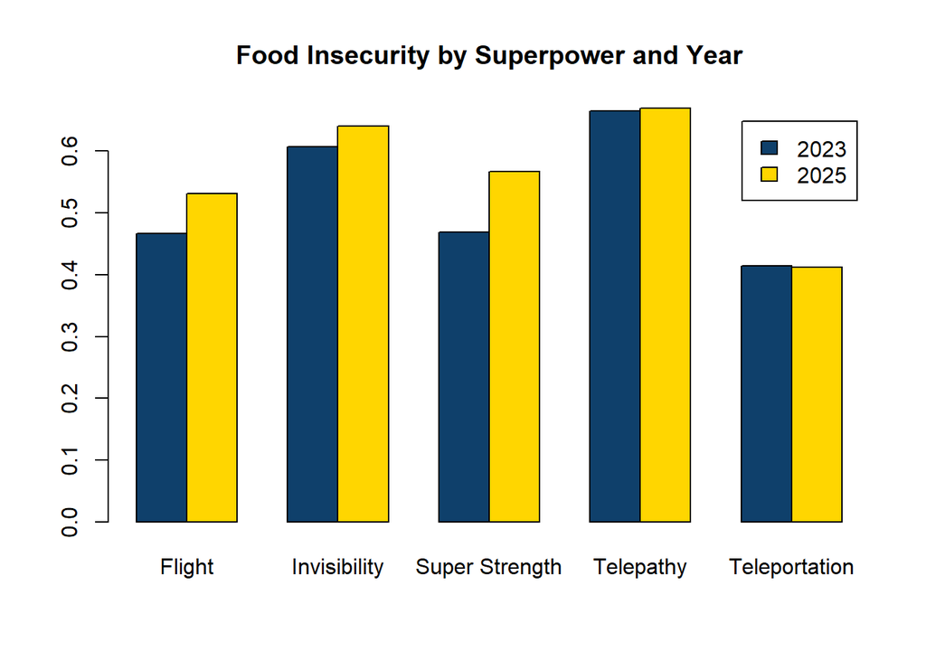

Figure 1

```r
# Reshape into a table: rows = outcomes, columns = superpowers

# Food Insecurity
rate_tab_food <- tapply(
  df_rates$rate[df_rates$outcome == "Food Insecurity"],  # values to summarise
  list(df_rates$year[df_rates$outcome == "Food Insecurity"],  # rows of the matrix -> bar groups
       df_rates$superpower[df_rates$outcome == "Food Insecurity"]), # columns -> x-axis positions
  identity #return value as is
)

barplot(rate_tab_food, beside = T,
        col = fc_colors[c("Blue", "Yellow")],
        main = "Food Insecurity by Superpower and Year",
        legend.text = c("2023", "2025"))

# same code below, just diff variables... copy/paste

# # Housing Insecurity
# rate_tab_housing <- tapply(
#   df_rates$rate[df_rates$outcome == "Housing Insecurity"],
#   list(df_rates$year[df_rates$outcome == "Housing Insecurity"],
#        df_rates$superpower[df_rates$outcome == "Housing Insecurity"]),
#   identity
# )

# barplot(rate_tab_housing, beside = TRUE,
#         col = fc_colors[c("Blue", "Yellow")],
#         ylim = c(0, 1),
#         main = "Housing Insecurity by Superpower and Year",
#         legend.text = c("2023", "2025"))

# # Homelessness
# rate_tab_homeless <- tapply(
#   df_rates$rate[df_rates$outcome == "Homelessness"],
#   list(df_rates$year[df_rates$outcome == "Homelessness"],
#        df_rates$superpower[df_rates$outcome == "Homelessness"]),
#   identity
# )

# barplot(rate_tab_homeless, beside = TRUE,
#         col = fc_colors[c("Blue", "Yellow")],
#         ylim = c(0, 1),
#         main = "Homelessness by Superpower and Year",
#         legend.text = c("2023", "2025"))

# # Any Insecurity
# rate_tab_any <- tapply(
#   df_rates$rate[df_rates$outcome == "Any Insecurity"],
#   list(df_rates$year[df_rates$outcome == "Any Insecurity"],
#        df_rates$superpower[df_rates$outcome == "Any Insecurity"]),
#   identity
# )

# barplot(rate_tab_any, beside = TRUE,
#         col = fc_colors[c("Blue", "Yellow")],
#         ylim = c(0, 1),
#         main = "Any Insecurity by Superpower and Year",
#         legend.text = c("2023", "2025"))

# use this code below if you're not sure what you can do with the barplot() function for R help.
# ?barplot
```

It’s pretty basic, but it’s great for exploration if you don’t care about aesthetics and just want to see the data. It gives meh vibes but importantly, it works.

Note: there’s a lot you CAN customize, but it’s less intuitive, more clunky. For example, I can add bar labels using base R, but I’ll be showing an easier way through ggplot2.

## Using ggplot2

Here are the graphs but made using ggplot2.

There’s a lot more customization we can do with ggplot2, and we can also create different types of visualizations, but this is a good starting point for creating a more polished bar chart to visualize the rates of basic needs insecurity by superpower.

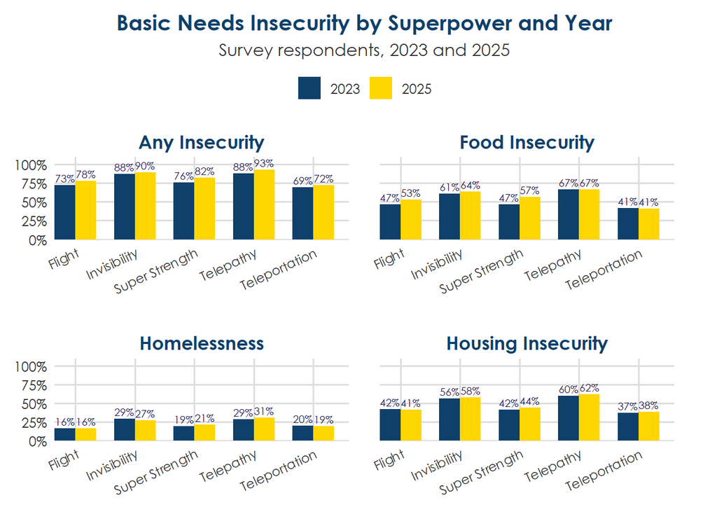

Figure 2

```r
ggplot(df_rates, aes(x = superpower, y = rate, fill = factor(year))) +

  geom_col(
    position = position_dodge(width = 0.7),
    width = 0.7
  ) +

  facet_wrap(
    ~outcome,
    ncol = 2,
     scales = "free_x" # so all graphs have x axis labels
  ) +

  geom_text(
    aes(label = paste0(round(rate * 100, 0), "%")),
    position = position_dodge(width = 0.7),
    vjust = -0.4,
    size = 2.5,
 #   fontface = "bold",
    color = "#1B0D42"
  ) +

  scale_fill_manual(
    values = c(
      "2023" = fc_colors[["Blue"]],
      "2025" = fc_colors[["Yellow"]]
    )
  ) +

  scale_x_discrete(
    expand = expansion(mult = c(0.05, 0.15))
  ) +

  scale_y_continuous(
    labels = scales::percent_format(accuracy = 1),
    limits = c(0, 1.1),
    expand = expansion(mult = c(0, 0))
  ) +

  labs(
    title = "Basic Needs Insecurity by Superpower and Year",
    subtitle = "Survey respondents, 2023 and 2025",
    x = NULL,
    y = NULL,
    fill = NULL
  ) +

  theme_fc() +

  theme(
    legend.position = "top",

    strip.text = element_text(
      size = 13,
      face = "bold",
      color = fc_colors[["Blue"]]
    ),

    plot.title = element_text(
      size = 15
    ),

    axis.text.x = element_text(
      angle = 25,
      hjust = 1,
      size = 9
    ),

    panel.spacing.x = unit(1.5, "lines"),
    panel.spacing.y = unit(1.5, "lines"),

    plot.margin = margin(
      t = 10,
      r = 30,
      b = 10,
      l = 10
    )
  )
```

If you want **static plots** (e.g., printed report, pdf, powerpoint), ggplot2 is a great choice.

If you want **interactive plots** (e.g., web dashboard), plotly is a great choice.

## Using plotly

Now let’s get started on plotly.

### Multiple bar graphs

This first graph is to replicate the ggplot2 graph above. This isn’t a graph I would usually show because it’s too messy, but here it is. It separates the graphs based on their outcomes.

Note: you can make it prettier, but I didn’t want to invest much into this viz.

```r
outcome_plots <- lapply(unique(df_rates$outcome), function(oc) {

  df_oc <- df_rates %>% filter(outcome == oc) # filter by outcome

  plot_ly(
    data          = df_oc,
    x             = ~superpower,
    y             = ~rate,
    color         = ~factor(year),
    legendgroup = ~factor(year),
    colors        = c("2023" = fc_colors[["Blue"]], "2025" = fc_colors[["Yellow"]]),
    type          = "bar",
    text          = ~paste0(round(rate * 100, 0), "%"),
    textposition  = "outside",
    cliponaxis    = FALSE,
    textfont      = list(color = "#242424 ", size = 11),
    customdata    = ~paste0(round(rate * 100, 1), "% (", year, ")<br>",
                            n, " of ", total),
hovertemplate = paste0(
  "<b style='color:#FFD600;'>%{x}</b><br>%{customdata} respondents<extra></extra>"),
    showlegend    = oc == unique(df_rates$outcome)[1]
  ) %>%
    layout(
      barmode = "group",
    margin  = list(t = 110, l = 10, r = 10, b = 40),
      xaxis   = list(title = ""),
      yaxis   = list(
        title      = "",
        tickformat = ".0%",
        range      = c(0, 1.10)
      ),
      annotations = list(list(
        text      = paste0("<b>", oc, "</b>"),
        x         = 0.5,
        y         = .98,
        xref      = "paper",
        yref      = "paper",
        showarrow = FALSE,
        xanchor   = "center",
        font      = list(size = 13, color = fc_colors[["Blue"]], family = "Century Gothic")
      ))
    )
})

fig_facet <- subplot(
  outcome_plots,
  nrows  = 2,
  shareY = FALSE,
  shareX = FALSE,
  titleX = TRUE,
  titleY = TRUE,
  margin = 0.08) %>%
  layout(
    autosize = TRUE,
    title = list(
      text = "<b>Basic Needs Insecurity by Superpower and Year</b>",
      font = list(size = 20)
    ),
    legend = list(
      orientation = "h",
      x = .5, xanchor = "center",
      y = 1.08)
  ) %>%
  fc_plotly_theme()


# alt text for accessibility

  alt_text <- paste0(
  "This is multiple bar charts. Pretend this describes the results."
)

htmltools::tags$div(
  role = "img",
  `aria-label` = alt_text,
  fig_facet)
```

[interactive chart not shown]

Figure 3

### Bar graph with dropdown menu

This is the same data as the clustered bar graph above. BUT this time, each outcome is split into its own graph, making it easier to view.

```r
rates_long <- df_expanded %>%
  filter(!is.na(superpower)) %>%
  group_by(superpower, year) %>%
  summarise(
    across(
      all_of(outcome_names),
      list(
        pct = ~round(100 * mean(., na.rm = TRUE), 1),
        n   = ~n_distinct(student_id)
      ),
      .names = "{.col}__{.fn}"
    ),
    .groups = "drop"
  ) %>%
  pivot_longer(
    cols      = -c(superpower, year),
    names_to  = c("outcome", ".value"),
    names_sep = "__"
  ) %>%
  left_join(year_totals, by = "year") %>%
  mutate(
    outcome_label = outcome_map[outcome],
    custom = paste0(n, " of ", total)
  )

year_colors <- c(
  "2023" = fc_colors[["Blue"]],
  "2025" = fc_colors[["Yellow"]]
)

years <- sort(unique(rates_long$year))

initial_outcome <- 4

n_traces <- length(outcome_names) * length(years)

fig_outcomes <- plot_ly(
  showlegend = TRUE,
  width = 800
)

for (i in seq_along(outcome_names)) {

  for (yr in years) {

    df_i <- rates_long %>%
      filter(
        outcome == outcome_names[i],
        year == yr
      ) %>%
      arrange(pct)

    fig_outcomes <- fig_outcomes %>%
      add_bars(
        data = df_i,
        x = ~superpower,
        y = ~pct,

        name = as.character(yr),
        legendgroup = as.character(yr),

        showlegend = (i == initial_outcome),

        text = ~paste0(pct, "%"),
        textposition = "outside",
        cliponaxis = FALSE,

        customdata = ~custom,

        hovertemplate = paste0(
          "<b style='color:#FFD600;'>%{x}, ",
          as.character(yr),
          ":</b> %{y}%<br>",
          "%{customdata} respondents",
          "<extra></extra>"
        ),

        marker = list(
          color = year_colors[[as.character(yr)]]
        ),

        visible = (i == initial_outcome)
      )
  }
}

## fml this button_outcomes is only for the legend... to make sure it shows on all dropdowns..

buttons_outcomes <- lapply(seq_along(outcome_names), function(i) {

  vis <- rep(FALSE, n_traces)
  showleg <- rep(FALSE, n_traces)

  idx <- ((i - 1) * length(years) + 1):(i * length(years))

  vis[idx] <- TRUE
  showleg[idx] <- TRUE

  list(
    method = "restyle",
    args = list(
      list(
        visible = vis,
        showlegend = showleg
      )
    ),
    label = outcome_labels[i]
  )
})

sp_order_outcomes <- rates_long %>%
  filter(outcome == "any_insecurity") %>%
  arrange(desc(pct)) %>%
  pull(superpower) %>%
  unique()

fig_outcomes <- fig_outcomes %>%
  layout(
    barmode = "group",

    margin = list(
      t = 100,
      l = 60,
      r = 40,
      b = 40),

    yaxis = list(
      title = "% of Students",
      range = c(0, 115)),

    xaxis = list(
      title = "",
      categoryorder = "array",
      categoryarray = sp_order_outcomes),

    legend = list(
      orientation = "h",
      x = 0.05, xanchor = "left",
      y = 1.1, yanchor = "top"    ),

    annotations = list(
      list(
        text = "<b>Select Insecurity Outcome:</b>",
        x = 0.5,
        y = 1.25,
        xref = "paper",
        yref = "paper",
        showarrow = FALSE,
        xanchor = "center",
        font = list(
          size = 13,
          color = fc_gray
        )
      )
    ),

    updatemenus = list(
      list(
        type = "dropdown",
        active = initial_outcome - 1,
        x = 0.5,
        y = 1.10,
        xref = "paper",
        yref = "paper",
        xanchor = "center",
        font = list(size = 13),
        buttons = buttons_outcomes
      )
    ),

    autosize = TRUE
  ) %>%
  config(responsive = TRUE) %>%
  fc_plotly_theme()



alt_text <- paste0(
  "This is another bar chart but with a dropdown. Pretend this describes the results."
)

htmltools::tagList(
  htmltools::tags$div(
    role = "img",
    `aria-label` = alt_text,
    fig_outcomes
  )
)
```

[interactive chart not shown]

### Horizontal bar graph with dropdown menu

Just turning the bars for fun.

```r
rates_long <- df_expanded %>%
  filter(!is.na(superpower)) %>%
  group_by(superpower, year) %>%
  summarise(
    across(
      all_of(outcome_names),
      list(
        pct   = ~round(100 * mean(., na.rm = TRUE), 1),
        n     = ~n_distinct(student_id)  # unique students in this superpower × year
      ),
      .names = "{.col}__{.fn}"
    ),
    .groups = "drop"
  ) %>%
  pivot_longer(
    cols      = -c(superpower, year),
    names_to  = c("outcome", ".value"),
    names_sep = "__"
  ) %>%
  left_join(year_totals, by = "year") %>%  # adds total unique students per year
  mutate(
    outcome_label = outcome_map[outcome],
    custom        = paste0(n, " of ", total)
  )

year_colors <- c("2023" = fc_colors[["Blue"]], "2025" = fc_colors[["Yellow"]])
n_traces    <- length(outcome_names) * length(years)

fig_outcomes <- plot_ly(showlegend = TRUE, width = 800)

years <- sort(unique(rates_long$year), decreasing = TRUE)

trace_index <- 0
for (i in seq_along(outcome_names)) {
  for (yr in years) {
    trace_index <- trace_index + 1

    df_i <- rates_long %>%
      filter(outcome == outcome_names[i], year == yr) %>%
      arrange(pct)

    fig_outcomes <- fig_outcomes %>%
      add_bars(
        data          = df_i,
        x             = ~pct,
        y             = ~reorder(superpower, pct),
        name          = as.character(yr),
        legendgroup   = as.character(yr),       # group by year across all outcomes
        showlegend    = TRUE,                 # legend tied to visible outcome
        orientation   = "h",
        text          = ~paste0(pct, "%"),
        textposition  = "outside",
        cliponaxis    = FALSE,
        customdata    = ~custom,
        hovertemplate = paste0(
  "<b style='color:#FFD600;'>%{y}, ",
  as.character(yr), ": </b>",
  "%{x}%<br>%{customdata} respondents<extra></extra>"),
        marker        = list(color = year_colors[[as.character(yr)]]),
        visible       = i == 4
      )
  }
}

buttons_outcomes <- lapply(seq_along(outcome_names), function(i) {
  vis <- rep(FALSE, n_traces)
  vis[((i - 1) * length(years) + 1):(i * length(years))] <- TRUE
  list(
    method = "update",
    label  = outcome_labels[i],
    args   = list(list(visible = as.list(vis)))
  )
})

fig_outcomes <- fig_outcomes %>%
  layout(
    barmode = "group",
    margin  = list(t = 80, l = 160),
    xaxis   = list(title = "% of Students", range = c(0, 115)),
    yaxis   = list(title = ""),
    legend  = list(
      orientation = "h",
      x = 0.05, xanchor = "left",
      y = 1.15, yanchor = "top",
      traceorder="reversed"),
    annotations = list(list(
      text      = "<b>Select Insecurity Outcome:</b>",
      x = 0.5, y = 1.3,
      xref = "paper", yref = "paper",
      showarrow = FALSE, xanchor = "center",
      font = list(size = 13, color = fc_gray)
    )),
    updatemenus = list(list(
      type    = "dropdown",
      active  = 3,
      x = 0.5, y = 1.17,
      xref = "paper", yref = "paper",
      xanchor = "center",
      font    = list(size = 13),
      buttons = buttons_outcomes
    )),
    autosize = TRUE
  ) %>%
  config(responsive = TRUE) %>%
  fc_plotly_theme()


alt_text <- paste0(
  "Whoa, the bars are sideways Pretend this describes the results."
)

htmltools::tagList(
  htmltools::tags$div(
    role = "img",
    `aria-label` = alt_text,
    fig_outcomes
  )
)
```

[interactive chart not shown]

### Heatmap

Next up is a heatmap to give us an overall view of what is happening. This heatmap has five different color levels/scales. Colors are scaled relative to each outcome’s mean so that each outcome is scaled differently since 60% in homelessness is very different from 60% in food insecurity in terms of severity.

```r
#creating the data table with the variables
heat_data <- df_expanded %>%
  filter(!is.na(superpower)) %>%
  group_by(superpower) %>%
  summarise(
    across(
      all_of(outcome_names),
      list(
        pct   = ~round(100 * mean(., na.rm = TRUE), 1),
        n     = ~sum(., na.rm = TRUE),
        total = ~sum(!is.na(.))),
      .names = "{.col}__{.fn}"),
    .groups = "drop")

sp_order <- heat_data %>%
  arrange(desc(any_insecurity__pct)) %>%
  pull(superpower)

#pivoting
heat_long <- heat_data %>%
  pivot_longer(
    cols      = -superpower,
    names_to  = c("outcome", ".value"),
    names_sep = "__") %>%
  mutate(
    outcome_label = factor(outcome_map[outcome], levels = rev(outcome_labels)),
    superpower    = factor(superpower, levels = sp_order))


# 5-step bins need to be centered on mean

# Set midpoints based on means

midpoints <- df %>%
  summarise(across(all_of(outcome_names), ~round(100 * mean(., na.rm = TRUE), 1))) %>%
  unlist()

#creating heat map color spectrum/breaks
heat_long <- heat_long %>%
  group_by(outcome) %>%
  mutate(
    mid      = midpoints[outcome[1]],
    rng      = max(max(pct, na.rm = TRUE) - mid, mid - min(pct, na.rm = TRUE), 10),
    slice    = rng / 5,
    step_bin = as.numeric(cut(
      pct,
      breaks         = unique(c(-Inf,
                        mid - 2 * slice,
                        mid - 0.5 * slice,
                        mid + 0.5 * slice,
                        mid + 2 * slice,
                        Inf)),
      labels         = FALSE,
      include.lowest = TRUE
    ))
  ) %>%
  ungroup()

# defining stuff
sp_levels        <- levels(heat_long$superpower)
outcomes_ordered <- outcome_names

# creating empty matrices with the outcomes
pct_mat   <- matrix(NA, nrow = length(sp_levels), ncol = length(outcomes_ordered)) #raw %
step_mat  <- matrix(NA, nrow = length(sp_levels), ncol = length(outcomes_ordered)) #steps
hover_mat <- matrix("", nrow = length(sp_levels), ncol = length(outcomes_ordered)) #hoverstring
text_mat  <- matrix("", nrow = length(sp_levels), ncol = length(outcomes_ordered)) #label for cell

for (i in seq_along(sp_levels)) {
  for (j in seq_along(outcomes_ordered)) {
    row <- heat_long %>%
      filter(superpower == sp_levels[i], outcome == outcomes_ordered[j])
    if (nrow(row) > 0) {
      pct_mat[i, j]   <- row$pct
      step_mat[i, j]  <- row$step_bin
      hover_mat[i, j] <- paste0(
        "<b><span style='color:#FFD600;'>",
        outcome_map[outcomes_ordered[j]], ": ", row$pct, "%</span></b><br>",
        row$n, " of ", row$total, " respondents")
      text_mat[i, j]  <- paste0(row$pct, "%")
    }}}

# Colorscale: yellow (low) → dark blue (high)
cs <- list(
  list(0.00, fc_colors[["Yellow"]]),
  list(0.25, fc_colors[["LemonZest"]]),
  list(0.50, fc_colors[["Breeze"]]),
  list(0.75, fc_colors[["Sky"]]),
  list(1.00, fc_colors[["Blue"]])
)

# Making the heatmap finally
plot_heatmap <- plot_ly(
  x            = outcome_labels,
  y            = sp_levels,
  z            = step_mat,
  type         = "heatmap",
  colorscale   = cs,
  zmin = 1, zmax = 5,
  showscale    = TRUE,
 colorbar     = list(
    tickvals   = c(1, 5),
    ticktext   = c("Low", "High"),
    title      = list(text = "<b>Relative to<br>average</b>", font = list(size = 11)),
    thickness  = 15,
    len        = 0.5
  ),
  text         = text_mat,
  texttemplate = "%{text}",
  textfont     = list(size = 12),
  hovertext    = hover_mat,
  hoverinfo    = "text",
  xgap = 3, ygap = 3,
  width = 800
) %>%
  layout(
    title    = list(text = "<b>Basic Needs Insecurity by Superpower</b>", font = list(size = 16)),
    xaxis    = list(title = ""),
    yaxis    = list(title = "", autorange = "reversed"),
    autosize = TRUE,
   margin  = list(l = 60, r = 40, t = 60, b = 60)
  ) %>%
  config(responsive = TRUE) %>%
  fc_plotly_theme()



alt_text <- paste0(
  "This is a heatmap. Pretend this describes the results."
)

htmltools::tagList(
  htmltools::tags$div(
    role = "img",
    `aria-label` = alt_text,
    plot_heatmap
  )
)
```

[interactive chart not shown]

### Bar graph with toggle

Suppose we want to know about the demographics. I thought it’d be fun to have students with two or more superpowers and allow us to “toggle” between how we count superpowers.

One graph is the “exclusive” way of counting superpowers, where students in each category selected only that category. Students with two or more superpowers are in the “2+ Superpowers” category.

Another graph is the “inclusive” way of counting superpowers, where students are included in all the categories they identify with.

```r
# demographics bar chart

demo_exclusive <- df %>%
  filter(!is.na(superpower)) %>%
  mutate(superpower = ifelse(grepl(",", superpower), "2+ Superpowers", superpower)) %>%
  count(superpower) %>%
  mutate(
    total   = sum(n),
    Percent = round(100 * n / sum(n), 1)) %>%
  arrange(desc(Percent))

demo_inclusive <- df_expanded %>%
  filter(!is.na(superpower), superpower != "2+ Superpowers") %>%
  count(superpower) %>%
  mutate(
    total   = nrow(df),
    Percent = round(100 * n / nrow(df), 1)) %>%
  arrange(desc(Percent))

# Pre-compute y orders for each trace
y_exclusive <- demo_exclusive %>% arrange(Percent) %>% pull(superpower)
y_inclusive <- demo_inclusive %>% arrange(Percent) %>% pull(superpower)

plot_demo <- plot_ly(showlegend = FALSE,width = 800) %>%

  add_bars(
    data          = demo_exclusive,
    x             = ~Percent,
    y             = ~reorder(superpower, Percent),
    orientation   = "h",
    text          = ~paste0(Percent, "%"),
    textposition  = "outside",
    cliponaxis    = FALSE,
    customdata    = ~paste0(n, " of ", total),
    hovertemplate = "<b style='color:#FFD600;'>%{y}:</b> %{x}%<br>%{customdata} respondents<extra></extra>",
    marker        = list(color = fc_colors[["Blue"]]),
    visible       = TRUE,
    name          = "Exclusive") %>%

  add_bars(
    data          = demo_inclusive,
    x             = ~Percent,
    y             = ~reorder(superpower, Percent),
    orientation   = "h",
    text          = ~paste0(Percent, "%"),
    textposition  = "outside",
    cliponaxis    = FALSE,
    customdata    = ~paste0(n, " of ", total),
    hovertemplate = "<b style='color:#FFD600;'>%{y}:</b> %{x}%<br>%{customdata} respondents<extra></extra>",
    marker        = list(color = fc_colors[["Creek"]]),
    visible       = FALSE,
    name          = "Inclusive") %>%

  layout(
    title  = list(text = "<b>Superpowers in CAMP Students</b>", font = list(size = 16)),
    margin = list(l = 120, r = 40, t = 90, b = 60),
    xaxis  = list(title = "% of Respondents", range = c(0, max(demo_inclusive$Percent) * 1.2)),
    yaxis  = list(
      title         = "",
      categoryorder = "array",
      categoryarray = y_exclusive),
    autosize = TRUE,

    updatemenus = list(list(
      type      = "buttons",
      direction = "right",
      x = -.1, y = 1.25,
      xref = "paper", yref = "paper",
      xanchor = "left",
      font    = list(size = 12),
      buttons = list(
        list(
          label  = "Exclusive",
          method = "update",
          args   = list(
            list(visible = list(TRUE, FALSE)),
            list(
              yaxis = list(categoryorder = "array", categoryarray = y_exclusive),
              title = list(text = "<b>Superpowers in CAMP Students</b><br>
              <sup>Students with 2 superpowers in '2+ Superpowers' category</sup>")
            ))),
        list(
          label  = "Inclusive",
          method = "update",
          args   = list(
            list(visible = list(FALSE, TRUE)),
            list(
              yaxis = list(categoryorder = "array", categoryarray = y_inclusive),
              title = list(text = "<b>Superpowers in CAMP Students</b><br><sup>
              Students with 2 superpowers counted in each</sup>")
            ))))))) %>%
  config(responsive = TRUE) %>%
  fc_plotly_theme()



# making the alt text

top_cat     <- demo_exclusive$superpower[1]
top_pct     <- demo_exclusive$Percent[1]

alt_text_demo <- paste0(
  "Horizontal bar chart of superpowers reported by CAMP students. ",
  top_cat, " is the most common at ", top_pct, "%. ",
  "A toggle switches between counting students with multiple superpowers ",
  "once under '2+ Superpowers' (Exclusive view) or under each superpower ",
  "they reported (Inclusive view)."
)


htmltools::tagList(
  htmltools::tags$div(
    role = "img",
    `aria-label` = alt_text_demo,
    plot_demo
  )
)
```

[interactive chart not shown]

### Another bar chart with a dropdown

Here’s another bar chart with a dropdown. This time, the legend is on the bottom, and there is different hover text. (We’re also looking at different variables.)

With the hover, if we can calculate it, we can include it in the hover. Your limitation is your imagination.

```r
# For each insecurity type, show retain and persist rates side by side,

# Compute retain and persist rates for each insecurity variable × status
outcomes_sis <- c("retain", "persist")

insec_long <- purrr::map_dfr(names(outcome_map), function(ins_var) {
  df %>%
    filter(!is.na(.data[[ins_var]]), !is.na(retain), !is.na(persist)) %>%
    group_by(status = .data[[ins_var]]) %>%
    summarise(
      retain  = round(100 * mean(retain,  na.rm = TRUE), 1),
      persist = round(100 * mean(persist, na.rm = TRUE), 1),
      n       = n(),
      .groups = "drop"
    ) %>%
    mutate(
      insecurity_var   = ins_var,
      insecurity_label = outcome_map[ins_var],
      status_label     = ifelse(status == 1, "Insecure", "Not Insecure")
    )
}) %>%
  pivot_longer(
    cols      = all_of(outcomes_sis),
    names_to  = "sis_outcome",
    values_to = "pct"
  ) %>%
  mutate(
    sis_label  = recode(sis_outcome, retain = "Retained", persist = "Persisted"),
    custom     = paste0("n = ", n)
  )

# Compute pp gap (Insecure minus Not Insecure) per insecurity var × sis outcome
insec_long <- insec_long %>%
  group_by(insecurity_var, sis_outcome) %>%
  mutate(
    gap = pct - pct[status_label == "Not Insecure"],  # positive = higher than not insecure
    gap_html = case_when(
      gap > 0 ~ paste0("<span style='color:#2ecc71;'>+", round(gap, 1), " pp</span>"),
      gap < 0 ~ paste0("<span style='color:#e74c3c;'>",  round(gap, 1), " pp</span>"),
      TRUE    ~ "0 pp"
    ),
    # Pack both n and gap into customdata as a separator-delimited string
    custom = paste0("n = ", n, "|", gap_html)
  ) %>%
  ungroup()


# One trace per insecurity variable × status combination, toggled by dropdown
trace_combos <- insec_long %>%
  distinct(insecurity_var, insecurity_label) %>%
  arrange(insecurity_var)

fig_insec <- plot_ly(showlegend = TRUE, width = 600)

trace_index <- 0
visible_default <- c()

for (i in seq_len(nrow(trace_combos))) {
  ins_var   <- trace_combos$insecurity_var[i]
  ins_label <- trace_combos$insecurity_label[i]

  for (st in c("Not Insecure", "Insecure")) {
    trace_index <- trace_index + 1

    # ONE df_t assignment only
    df_t <- insec_long %>%
      filter(insecurity_var == ins_var, status_label == st) %>%
      mutate(
        custom = ifelse(
          status_label == "Not Insecure",
          paste0("n = ", n),
          paste0("n = ", n, "<br>vs. Not Insecure: ", gap_html)
        )
      )

    is_visible <- i == 1
    visible_default <- c(visible_default, is_visible)

    fig_insec <- fig_insec %>%
      add_bars(
        data          = df_t,
        x             = ~sis_label,
        y             = ~pct,
        name          = st,
        text          = ~paste0(pct, "%"),
        textposition  = "outside",
        cliponaxis    = FALSE,
        customdata    = ~custom,
        hovertemplate = paste0(
          "<b style='color:#FFD600;'>", st, "</b><br>",
          "%{x}: <b>%{y}%</b><br>",
          "%{customdata}<extra></extra>"
        ),
        marker = list(color = ifelse(
          st == "Not Insecure",
          fc_colors[["Blue"]],
          fc_colors[["Yellow"]]
        )),
        visible = is_visible)
  }}

# Build dropdown buttons — each button shows 2 traces (Not Insecure + Insecure)
n_traces    <- trace_index
n_per_group <- 2  # one trace per status per insecurity var

buttons_insec <- lapply(seq_len(nrow(trace_combos)), function(i) {
  vis <- rep(FALSE, n_traces)
  vis[((i - 1) * n_per_group + 1):(i * n_per_group)] <- TRUE
  list(
    method = "update",
    label  = trace_combos$insecurity_label[i],
    args   = list(list(visible = as.list(vis)))
  )
})

fig_insec <- fig_insec %>%
  layout(
    barmode = "group",
    margin  = list(l = 80, r = 40, t = 120, b = 60),
    xaxis   = list(title = ""),
    yaxis   = list(title = "% of Students", range = c(0, 105)),
    legend  = list(
      orientation = "h",
      x = 0.5, xanchor = "center",
      y = -0.15
    ),
    annotations = list(list(
      text      = "<b>Select Insecurity Outcome:</b>",
      x = 0.5, y = 1.18,
      xref = "paper", yref = "paper",
      showarrow = FALSE, xanchor = "center",
      font = list(size = 13, color = fc_gray)
    )),
    updatemenus = list(list(
      type    = "dropdown",
      active  = 0,
      x = 0.5, y = 1.10,
      xref = "paper", yref = "paper",
      xanchor = "center",
      font    = list(size = 13),
      buttons = buttons_insec
    )),
    autosize = TRUE
  ) %>%
  config(responsive = TRUE) %>%
  fc_plotly_theme()



alt_text <- paste0(
  "So do we get the hang of alt texts now? Pretend this describes the results."
)

htmltools::tagList(
  htmltools::tags$div(
    role = "img",
    `aria-label` = alt_text,
    fig_insec
  )
)
```

[interactive chart not shown]

# Accessibility

Accessibility is not determined by the plotting package alone. Regardless of whether you use Base R, ggplot2, or Plotly, accessible visualizations should still:

- Include meaningful titles, which I NOT do in this tutorial.
- Use sufficient color contrast.
- Avoid relying on color (e.g., use shapes).
- Use readable font sizes. – also did not consistently do in this tutorial.
- Provide descriptive alt text.
- Keep unnecessary visual clutter to a min.

| Accessibility Feature | Base R | ggplot2 | Plotly |
| --- | --- | --- | --- |
| **Alt text support** | Manual (outside the figure) | Supported through Quarto (`fig-alt`) | Manual (`aria-label`, HTML wrapper) |
| **Screen reader support** | Limited | Good for static reports when rendered with Quarto | Requires additional HTML/ARIA attributes |
| **Keyboard navigation** | N/A (static image) | N/A (static image) | Supported by the browser, but interactive controls may require additional testing |
| **Interactive exploration** | No | No | Yes (hover, zoom, pan, legend toggles, dropdowns) |
| **Hover text** | No | No | Yes; can provide additional context without cluttering the figure |
| **Colorblind-friendly palettes** | Manual | Easy (`scale_*()`, ColorBrewer, viridis, custom palettes) | Easy (inherits colors from ggplot or custom Plotly colors) |
| **Readable fonts and sizing** | Manual | Easy through themes | Easy through layout options |
| **Direct data labels** | Possible but annoying af | Straightforward (`geom_text()`) | Straightforward (`text`, `textposition`) |
| **Figure captions** | Manual | Built into Quarto | Built into Quarto (outside the widget) |
| **Export to accessible PDF** | Yes | Excellent | Limited (typically better to include a static alternative) |
| **Recommended use** | Quick exploratory graphics | Accessible static reports (PDF, Word, PowerPoint) | Accessible HTML reports and dashboards with additional accessibility work |

# Notes on these vizzes

## Connecting and cleaning data

1. How do you connect to data? Are there options for joining/unions/filtering?

**Reading data**

Data is read from .csv files using “read.csv()”. I also use “here()”” from the here package to make the file paths more streamlined and since it sets the working directory to be the main folder we’re working out of.

There are lots of things you can do when reading in this data using read.csv(), including “header=F” if you don’t have a header; “na.strings = c(”NA”,“N/A”,““)”, depending on what you called your NA; skip = 3 (skip first 3 rows), etc. Just use “?read.csv” to learn more.

You can also read in SPSS .sav files (haven package) or Excel .xlsx files (readxl package). You can also connect directly to a database using DBI or ODBC packages and pull from an extract. For obvious purposes, that’s not done here.

After you have a dataframe and want to export it, I usually use write.csv() to create a .csv file or use the writexl package to write an .xlsx file.

**Joining/merging data**

First, you must have the data read into the dataframe (e.g., “df1 <- read.csv(something.csv)”).

Here’s example code on merging data: df <- merge(dataframe1, dataframe2, by = c(“common_variable1”, “common_variable2”, “up_to_however_many_you_want”), all.x = TRUE)

- “all.x = TRUE” is a left join, meaning to keep all rows on left side regardless of match
- “all.y = TRUE” is a right join
- “all = TRUE” is keep all rows regardless of match. It’s a full outer join
- If you don’t include anything, then you keep rows that match both tables ONLY. It’s an inner join.

There’s a lot more in cleaning data in R, but that’s beyond the scope of this. 10/10 recommend loading the tidyverse package, which includes multiple packages (e.g., dplyr, tidyr, stringr, ggplot2, forcats, etc.) instead of manually loading individual packages.

## Creating a simple chart

2. What are the steps in creating a simple chart?

First, you need to have a clean dataset, summarize it into the shape the chart needs, map variables to visual properties (x, y, fill), add labels/formatting/theme.

But of course, we don’t just want a simple chart. I use **ggplot2** and **plotly** packages.

HEre’s what chat says about the difference between the two:

“ggplot2 is built around the grammar of graphics — a layered system where you build a plot by mapping variables to visual properties (aes()), then adding geometric layers (geom_col(), geom_point(), geom_line()), then adjusting scales, labels, and themes. It produces static images — great for printed reports, PDFs, and PowerPoints. The code is readable and consistent: every ggplot2 plot follows the same structure regardless of chart type.”

“plotly produces interactive HTML charts — users can hover for details, zoom, pan, and toggle traces on and off. It’s better suited for web reports, Quarto HTML output, and dashboards. The tradeoff is that the code is more verbose and layout tweaks (positioning dropdowns, adjusting margins, controlling hover text) require more trial and error.”

Note: the trial and error part is very accurate…

## Creating dashboards

3. For dashboards, how are pages developed? How are dashboard functions, such as filters, page selections, etc. created?

These aren’t dashboards, but all filters are in the code.

Data can be pre-filtered (i.e., hard-coded in that we select specific data to visualize) OR filtered in plotly (e.g., dropdown menu).

4. Can you provide a brief description of how you update visualizations/dashboards? Are the processes automated?

Since everything is all in the code, just replace the file (e.g., any .csv you want updated), ensuring the file name is the same (or create code that references the most recent file by number). Then re-run the code.

Everything is uploaded into GitHub for version control. However, for FERPA’s sake, there is a .gitignore file, so certain file types are never uploaded into GitHub (e.g., .csv, .xlsx). I also make sure to exclude certain folders (e.g., “data” folders) as an extra precaution.

## Other information

5. Please provide any information about best practices you follow, how you design with the user in mind, and/or tips and tricks.

Designing is about the story I’m trying to tell (and the data itself, of course).

- **What does the reader want to know?** This will tell us what elements to include. For example, having “inclusive” vs. “exclusive” superpower depends on the audience having two purposes for looking at the viz.
- **What else is the reader asking about?** Hover text should give additional details and answer questions that others might have.
- **What kind of report?** Static plots (ggplot2) work best for printed reports, pdfs, and powerpoints. Interactive plots (plotly) work best if the report is viewed online and give additional detail to a broader audience.
- **What kind of visualisation?** The data tells us this. E.g., bar charts for categorical comparisons, heatmaps for large overview, line graphs for trends, etc.
- **What do the design elements mean?** Colors should mean something. For instance, in the heatmap, each outcome’s color bins are relative to that specific outcome’s own mean, not a shared fixed scale.

### Pros and cons

Is this method of visualizing data all-purpose? Nope, so here are the pros and cons.

**Pros:**

- Once you’ve got a good set-up, it’s very easy to recreate reports since the code is already there.
- Version control friendly – code lives in Git, not in a spreadsheet or backup folder.
- Fully reproducable since you can regenerate any report from the same code and data.
- Parameterization means that if I have one tempalte, I can generate many many reports automatically (e.g., peronalized faculty reports).
- Extremely customizable with everything, from graphs to branding to how the report itself looks.
- Great for reports that use text to describe what is happening or the “message” you want them to takeaway.
- FREEEEEEEEEE. Budget cuts, anyone?

**Cons:**

- Huge start-up investment in time… from creating the code to ensuring the reports match how you want it to look (i.e., branding standards).
- Very technical. Difficult to modify unless you can read the code.
- Debugging sucks. If something breaks, you need to figure out where.
- Plotly interactive elements is all trial and error…
- Sharing reports requires rendering to html/pdf, and updates need re-rendering.

### Other files/code being referenced

To create a report such as this one, I have multiple files:

- report.qmd: this is the actual content file (this file I’m typing up). It’s the report itself with text, code chunks (and subsequent output), plots, tables, etc. This is what gets rendered. I can have multiple .qmd files that reference the files below to have the same “look” to them.
- _quarto.yml: the project/config file. This is where I tell Quarto to reference the .html and .css templates below.
- fullerton.html: This is a custom .html template, whcih controls the structure of the page, such as the header layout, logo placement, navigation bar on teh left, footer. This is essentially the skeleton that wraps around what I render from the .qmd file.
- fullerton.css: This is where the formatting lives, such as colors, fonts, spacing, custom classes for tables/buttons/etc. This is essentially the “branding” customization.

[figure not shown]